# Google Symptoms Dataset

### Explore potentially useful symptoms using linear regression

**Jingjing Tang** **2020-11-19**

```python
from IPython.display import HTML

HTML('''<script>
code_show=true;
function code_toggle() {
 if (code_show){
 $('div.input').hide();
 } else {
 $('div.input').show();
 }
 code_show = !code_show
}
$( document ).ready(code_toggle);
</script>
<form action="javascript:code_toggle()"><input type="submit" value="Click here to toggle on/off the raw code."></form>''')
```

```python
import re
import matplotlib.pyplot as plt
from datetime import datetime
from scipy.stats import spearmanr, rankdata
import seaborn as sns

import pandas as pd
import numpy as np

import statsmodels.api as sm
from statsmodels.tools import add_constant
from sklearn import preprocessing, ensemble, tree
from sklearn.metrics import mean_squared_error
from sklearn.model_selection import train_test_split
from sklearn.linear_model import LinearRegression
from sklearn.tree import export_graphviz

from delphi_utils import GeoMapper
import covidcast

gmpr = GeoMapper()
```

## Read the raw data

```python
## Helper function to read the data, borrow the one from google-symptoms pipeline
DC_FIPS = "11001"
base_url = "https://raw.githubusercontent.com/google-research/open-covid-19-data/master/data/exports/search_trends_symptoms_dataset/United%20States%20of%20America{sub_url}2020_US_{state}daily_symptoms_dataset.csv"
STATE_TO_ABBREV = {'Alabama':'al',
                   'Alaska': 'ak',
#                   'American Samoa': 'as',
                   'Arizona': 'az',
                   'Arkansas': 'ar',
                   'California': 'ca',
                   'Colorado': 'co',
                   'Connecticut': 'ct',
                   'Delaware': 'de',
#                   'District of Columbia': 'dc',
                   'Florida': 'fl',
                   'Georgia': 'ga',
#                   'Guam': 'gu',
                   'Hawaii': 'hi',
                   'Idaho': 'id',
                   'Illinois': 'il',
                   'Indiana': 'in',
                   'Iowa': 'ia',
                   'Kansas': 'ks',
                   'Kentucky': 'ky',
                   'Louisiana': 'la',
                   'Maine': 'me',
                   'Maryland': 'md',
                   'Massachusetts': 'ma',
                   'Michigan': 'mi',
                   'Minnesota': 'mn',
                   'Mississippi': 'ms',
                   'Missouri': 'mo',
                   'Montana': 'mt',
                   'Nebraska': 'ne',
                   'Nevada': 'nv',
                   'New_Hampshire': 'nh',
                   'New_Jersey': 'nj',
                   'New_Mexico':'nm',
                   'New_York': 'ny',
                   'North_Carolina': 'nc',
                   'North_Dakota': 'nd',
#                   'Northern Mariana Islands': 'mp',
                   'Ohio': 'oh',
                   'Oklahoma': 'ok',
                   'Oregon': 'or',
                   'Pennsylvania': 'pa',
#                   'Puerto Rico': 'pr',
                   'Rhode_Island': 'ri',
                   'South_Carolina': 'sc',
                   'South_Dakota': 'sd',
                   'Tennessee': 'tn',
                   'Texas': 'tx',
                   'Utah': 'ut',
                   'Vermont': 'vt',
#                   'Virgin Islands': 'vi',
                   'Virginia': 'va',
                   'Washington': 'wa',
                   'West_Virginia': 'wv',
                   'Wisconsin': 'wi',
                   'Wyoming': 'wy'}

def get_geo_id(region_code):
    """
    There are region code in the format of "US-state" and "US-state-fips". In
    county level report, we only consider rows with fips info provided.
    """
    splits = region_code.split("-")
    if len(splits) == 3:
        return splits[2]
    return np.nan

dfs = {}
# For state level data
df = pd.read_csv(base_url.format(sub_url="/", state=""), parse_dates = ["date"])
df["geo_id"] = df["open_covid_region_code"].apply(lambda x: x.split("-")[1].lower())
dfs["state"] = df

# For county level data
dfs["county"] = pd.DataFrame(columns = dfs["state"].columns)
for state in list(STATE_TO_ABBREV.keys()):
    sub_url = "/subregions/" + "%20".join(state.split("_")) + "/"
    df = pd.read_csv(base_url.format(sub_url=sub_url, state=state+"_"), parse_dates = ["date"])
    df["geo_id"] = df["open_covid_region_code"].apply(get_geo_id)
    dfs["county"] = dfs["county"].append(df)

# Add District of Columbia County
try:
    df_dc_county = dfs["state"][dfs["state"]["geo_id"]=="dc"].drop("geo_id", axis = 1)
    df_dc_county.loc[:, "geo_id"] = DC_FIPS
    dfs["county"] = dfs["county"].append(df_dc_county)
except KeyError:
    pass

dfs["state"].to_csv("state_google_symptoms.csv", index=False)
dfs["county"].to_csv("county_google_symptoms.csv", index=False)
```

## Correlation Across Location

Note that since the data is not comparable between regions (since the values are scaled based on region specific maximum values at a certain time point), we will only consider time-series correlation.

```python
# Read GS data
gs_df = pd.read_csv("county_google_symptoms.csv", parse_dates=["date"]).drop(
                      ['open_covid_region_code', 'country_region_code', 'country_region',
                       'sub_region_1', 'sub_region_1_code', 'sub_region_2',
                       'sub_region_2_code'],
                    axis = 1)
gs_df = gs_df[~gs_df["geo_id"].isnull()]
gs_df["geo_id"] = [str(int(x)).zfill(5) for x in gs_df["geo_id"]]

# Read case data from API
start_date = datetime(2020, 2, 20)
end_date = datetime(2020, 11, 9)
api_df = covidcast.signal("usa-facts", "confirmed_7dav_incidence_prop",
                        start_date, end_date, "county").rename(
                        {"geo_value":"geo_id", "value": "cases", "time_value": "date"},
                        axis = 1)[["geo_id", "date", "cases"]]
df = gs_df.merge(api_df, on=["date", "geo_id"])
```

```python
df.keys()
```

```
Index(['date', 'symptom:Abdominal obesity', 'symptom:Abdominal pain',
       'symptom:Acne', 'symptom:Actinic keratosis', 'symptom:Acute bronchitis',
       'symptom:Adrenal crisis', 'symptom:Ageusia', 'symptom:Alcoholism',
       'symptom:Allergic conjunctivitis',
       ...
       'symptom:Weakness', 'symptom:Weight gain', 'symptom:Wheeze',
       'symptom:Xeroderma', 'symptom:Xerostomia', 'symptom:Yawn',
       'symptom:hyperhidrosis', 'symptom:pancreatitis', 'geo_id', 'cases'],
      dtype='object', length=425)
```

```python
n_day = df["date"].unique().shape[0]
print("There are %d days considered in total"%n_day)
n_county = df["geo_id"].unique().shape[0]
print("There are %d counties considered in total"%n_county)
```

```
There are 264 days considered in total
There are 2726 counties considered in total
```

### For manually Selected 25 COVID-related Symptoms

It takes too long to run the correlation for all of the symptoms. Will start from a list of potentially COVID-related symptoms only (I took a rough look at all search terms and filtered them according to the relevant symptoms listed by [CDC](https://www.cdc.gov/coronavirus/2019-ncov/symptoms-testing/symptoms.html)) and then go back to brute-force.

```python
selected_predictors = ["symptom:Myalgia", "symptom:Chest pain", "symptom:Apnea", "symptom:Cough", "symptom:Phlegm",
        "symptom:Sputum", "symptom:Shortness of breath", "symptom:Tachypnea", "symptom:Shallow breathing",
        "symptom:Asphyxia", "symptom:Anosmia", "symptom:Ageusia", "symptom:Common cold", "symptom:Diarrhea",
        "symptom:Dysgeusia", "symptom:Hypoxia","symptom:Inflammation", "symptom:Laryngitis",
        "symptom:Muscle weakness", "symptom:Nasal congestion", "symptom:Nausea", "symptom:Pain",
        "symptom:Vomiting", "symptom:Fever", "symptom:Shivering"]
```

```python
print(selected_predictors)
```

```
['symptom:Myalgia', 'symptom:Chest pain', 'symptom:Apnea', 'symptom:Cough', 'symptom:Phlegm', 'symptom:Sputum', 'symptom:Shortness of breath', 'symptom:Tachypnea', 'symptom:Shallow breathing', 'symptom:Asphyxia', 'symptom:Anosmia', 'symptom:Ageusia', 'symptom:Common cold', 'symptom:Diarrhea', 'sympt…
```

```python
print("There are %d symptoms selected."%len(selected_predictors))
```

```
There are 25 symptoms selected.
```

### Linear Regression

```python
all_predictors = selected_predictors.copy()
X = df.loc[:, all_predictors].fillna(0)
y = df.loc[:, "cases"].fillna(0)
X_train, X_test, y_train, y_test = train_test_split(X, y, test_size=0.10, random_state=3)

# Train the model
reg = LinearRegression().fit(X_train.values , y_train)
pred = reg.predict( X_test.values )
mse = mean_squared_error(pred, y_test)
```

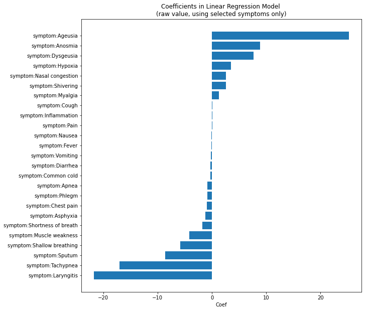

```python
sorted_idx = np.argsort(reg.coef_)
pos = np.arange(25) + .5

plt.figure(figsize = (10, 10))
plt.barh(pos, reg.coef_[sorted_idx][-25:], align='center')
plt.yticks(pos, np.array(all_predictors)[sorted_idx][-25:])
plt.xlabel('Coef')
plt.title('Coefficients in Linear Regression Model \n(raw value, using selected symptoms only)')
```

So in general, this is consistent with what we found in the correlation analysis.

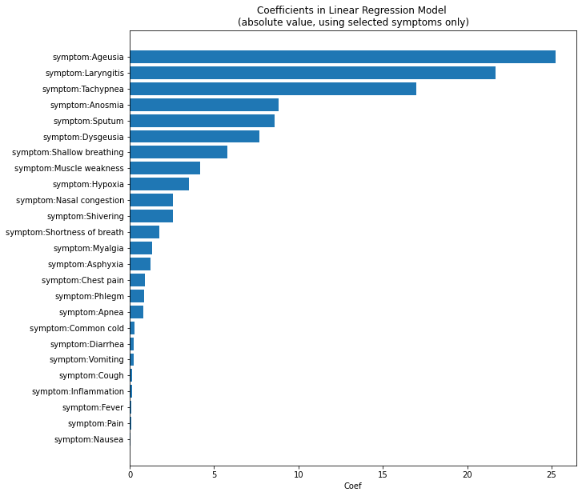

```python
coefs = [abs(x) for x in reg.coef_]
sorted_idx = np.argsort(coefs)
pos = np.arange(25) + .5

plt.figure(figsize = (10, 10))
plt.barh(pos, np.array(coefs)[sorted_idx][-25:], align='center')
plt.yticks(pos, np.array(all_predictors)[sorted_idx][-25:])
plt.xlabel('Coef')
plt.title('Coefficients in Linear Regression Model \n(absolute value, using selected symptoms only)')
```

### For All of the 422 symptoms

```python
i = 0
corr_df = pd.DataFrame(columns=["county", "symptom", "correlation", "pvalue"])
for idx in range(1, len(df.columns)-2):
    symptom = df.columns[idx].split(":")[1]
    subdf = df[[df.columns[idx], "cases", "geo_id"]].dropna()
    mask_df = subdf.groupby("geo_id").count()
    # Filter out counties with more than 80% days unavailable
    geo_list = set(mask_df[mask_df[df.columns[idx]] >= n_day*0.2].index.values)
    subdf = subdf[subdf["geo_id"].isin(set(geo_list))]
    for county in set(geo_list):
        local_df = subdf[subdf["geo_id"] == county]
        corr, p = spearmanr(list(local_df.values[:, 0]), list(local_df.values[:, 1]), nan_policy="omit")
        corr_df.loc[i] = [county, symptom, corr, p]
        i += 1
    print("Finished calculation for %s"%symptom)
corr_df.to_csv("GS_spearman_corr.csv", index=False)
```

```
Finished calculation for Abdominal obesity
Finished calculation for Abdominal pain
Finished calculation for Acne
Finished calculation for Actinic keratosis
Finished calculation for Acute bronchitis
Finished calculation for Adrenal crisis
Finished calculation for Ageusia
Finished calculation for Alcoholism
Finished calculation for Allergic conjunctivitis
Finished calculation for Allergy
Finished calculation for Amblyopia
Finished calculation for Amenorrhea
Finished calculation for Amnesia
Finished calculation for Anal fissure
Finished calculation for Anaphylaxis
Finished calculation for Anemia
Finished calculation for Angina pectoris
Finished calculation for Angioedema
Finished calculation for Angular cheilitis
Finished calculation for Anosmia
Finished calculation for Anxiety
Finished calculation for Aphasia
Finished calculation for Aphonia
Finished calculation for Apnea
Finished calculation for Arthralgia
Finished calculation for Arthritis
Finished calculation for Ascites
Finished calculation for Asperger syndrome
Finished calculation for Asphyxia
Finished calculation for Asthma
Finished calculation for Astigmatism
Finished calculation for Ataxia
Finished calculation for Atheroma
Finished calculation for Attention deficit hyperactivity disorder
Finished calculation for Auditory hallucination
Finished calculation for Autoimmune disease
Finished calculation for Avoidant personality disorder
Finished calculation for Back pain
Finished calculation for Bacterial vaginosis
Finished calculation for Balance disorder
```

[output cut: 367 more lines]

```
Finished calculation for Ventricular tachycardia
Finished calculation for Vertigo
Finished calculation for Viral pneumonia
Finished calculation for Visual acuity
Finished calculation for Vomiting
Finished calculation for Wart
Finished calculation for Water retention
Finished calculation for Weakness
Finished calculation for Weight gain
Finished calculation for Wheeze
Finished calculation for Xeroderma
Finished calculation for Xerostomia
Finished calculation for Yawn
Finished calculation for hyperhidrosis
Finished calculation for pancreatitis
```

```python
corr_df = pd.read_csv("GS_spearman_corr.csv")
sorted_mean = corr_df.groupby("symptom").mean().reset_index()[["symptom", "correlation"]]
sorted_std = corr_df.groupby("symptom").std().reset_index()[["symptom", "correlation"]]
sorted_median = corr_df.groupby("symptom").median().reset_index()[["symptom", "correlation"]]
summary_df = sorted_mean.merge(sorted_median, on="symptom", suffixes=["_mean", "_median"]
                       ).merge(sorted_std, on="symptom"
                       ).sort_values("correlation_mean", ascending=False
                       ).rename({"correlation": "correlation_std"}, axis=1)
summary_df
```

The table below shows the information extracted for COVID-related symptoms (pre-selected)

```python
summary_df["mean_rank"] = [x for x in range(1, summary_df.shape[0]+1)]
summary_df[summary_df["symptom"].isin([x.split(":")[1] for x in selected_predictors])]
```

|  | symptom | correlation_mean | correlation_median | correlation_std | mean_rank |
| --- | --- | --- | --- | --- | --- |
| 6 | Ageusia | 0.422655 | 0.470796 | 0.192589 | 1 |
| 19 | Anosmia | 0.365118 | 0.386319 | 0.205393 | 2 |
| 113 | Dysgeusia | 0.297478 | 0.309382 | 0.178085 | 4 |
| 212 | Hypoxia | 0.131509 | 0.090598 | 0.196036 | 24 |
| 290 | Pain | 0.070416 | 0.067277 | 0.164165 | 120 |
| 261 | Myalgia | 0.049240 | 0.052220 | 0.146129 | 166 |
| 267 | Nausea | 0.017768 | 0.021500 | 0.191434 | 242 |
| 349 | Shivering | 0.003600 | -0.006854 | 0.169475 | 280 |
| 260 | Muscle weakness | -0.007521 | 0.012664 | 0.129769 | 294 |
| 378 | Tachypnea | -0.026700 | -0.029492 | 0.160080 | 322 |
| 28 | Asphyxia | -0.050693 | -0.055274 | 0.111690 | 338 |
| 23 | Apnea | -0.054196 | -0.047497 | 0.112582 | 341 |
| 218 | Inflammation | -0.059110 | -0.046198 | 0.127935 | 343 |
| 74 | Chest pain | -0.085917 | -0.097870 | 0.136249 | 360 |
| 109 | Diarrhea | -0.099012 | -0.070799 | 0.194693 | 367 |
| 411 | Vomiting | -0.131024 | -0.112866 | 0.160318 | 377 |
| 347 | Shallow breathing | -0.139671 | -0.194581 | 0.225597 | 378 |
| 265 | Nasal congestion | -0.170352 | -0.154046 | 0.163805 | 386 |
| 350 | Shortness of breath | -0.233064 | -0.270926 | 0.176252 | 396 |
| 92 | Cough | -0.292344 | -0.293178 | 0.178757 | 407 |
| 141 | Fever | -0.300138 | -0.321956 | 0.162980 | 408 |
| 84 | Common cold | -0.326627 | -0.332423 | 0.194005 | 410 |
| 303 | Phlegm | -0.329287 | -0.371995 | 0.200739 | 411 |
| 364 | Sputum | -0.346376 | -0.397326 | 0.190469 | 413 |
| 234 | Laryngitis | -0.472556 | -0.462299 | 0.162208 | 422 |

It's kind of interesting to see that some of the symptoms that I selected turns out to have relatively large negative correlation with confirmed cases incidence prop which is counter-intuitive.

```python
target_symptoms = ["Laryngitis", "Sputum", "Phlegm", "Common cold", "Fever", "Cough", "Shortness of breath"]
```

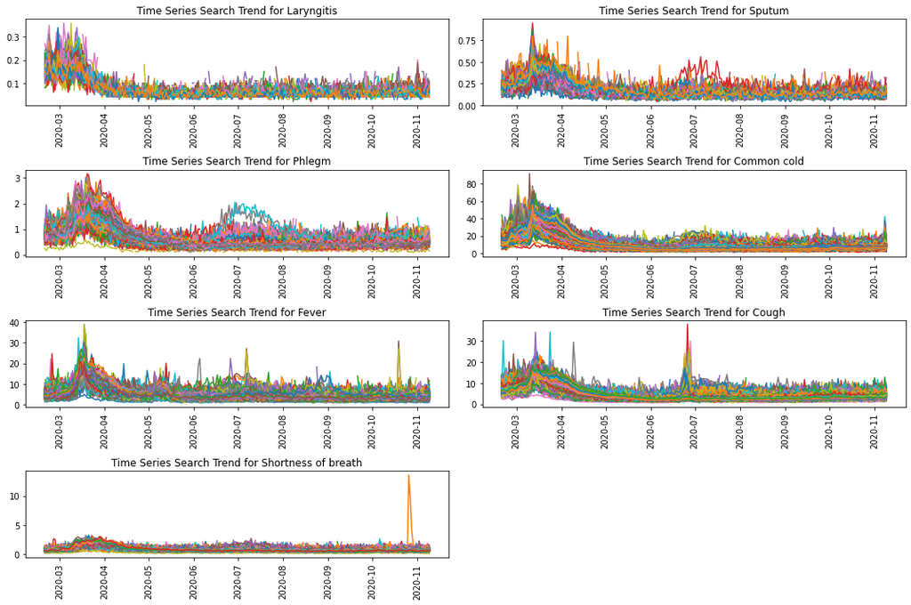

```python
plt.figure(figsize=(15, 10))

for i in range(len(target_symptoms)):
    plt.subplot(4,2,i+1)
    test_df = corr_df[corr_df["symptom"] == target_symptoms[i]].sort_values("correlation")
    for county in test_df["county"]:
        plt.plot(df[df["geo_id"] == str(county).zfill(5)]["date"],
                 df[df["geo_id"] == str(county).zfill(5)]["symptom:%s"%target_symptoms[i]])
        plt.xticks(rotation=90)
        plt.title("Time Series Search Trend for %s"%target_symptoms[i])
plt.tight_layout()
```

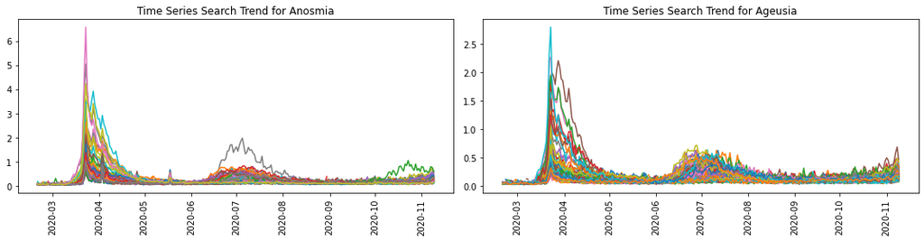

```python
target_symptoms = ["Anosmia", "Ageusia"]
plt.figure(figsize=(15, 4))

for i in range(len(target_symptoms)):
    plt.subplot(1,2,i+1)
    test_df = corr_df[corr_df["symptom"] == target_symptoms[i]].sort_values("correlation")
    for county in test_df["county"]:
        plt.plot(df[df["geo_id"] == str(county).zfill(5)]["date"],
                 df[df["geo_id"] == str(county).zfill(5)]["symptom:%s"%target_symptoms[i]])
        plt.xticks(rotation=90)
        plt.title("Time Series Search Trend for %s"%target_symptoms[i])
plt.tight_layout()
```

The negative correlation is caused by lag in time between the confirmation of cases and the appearance of the symptosm. When we calculate the spearman correlation, we don't add suitable time lag for different regions. There is an apparent increasing trand in mid March for confirmed cases. However, people usually search for symptoms such as `Laryngitis` several days early than cases being confirmed.

So, symptoms with large negative correlation are also important ones to look at. This might raise another interesting problm:

*The appearance of different symptoms has different effects on people's reaction.*

Anosmia and Ageusia stand out probably because they are special enough. People with relatively more common symptoms like `fever` and `cough` will not rush to get tested for COVID.

```python
all_predictors = df.columns[1:-2]
```

```python
print("There are %d symptoms selected."%len(all_predictors))
```

```
There are 422 symptoms selected.
```

```python
df = gmpr.add_geocode(df, "fips", "state_id", "geo_id")
```

### Linear Regression

#### Train on data for different state (ignore this part, not very useful)

```python
coef_raw_rank_df = pd.DataFrame(columns=(list(all_predictors) + ['mse', 'state']))
coef_abs_rank_df = pd.DataFrame(columns=(list(all_predictors) + ['mse', 'state']))
coef_df = pd.DataFrame(columns=(list(all_predictors) + ['mse', 'state']))
i = 0
best_predictor_set = [all_predictors]
for state in df["state_id"].unique():
    state_df = df[df["state_id"] == state]
    X = state_df.loc[:, all_predictors].fillna(0)
    y = state_df.loc[:, "cases"].fillna(0)
    X_train, X_test, y_train, y_test = train_test_split(X, y, test_size=0.10, random_state=3)

    # Train the model
    reg = LinearRegression().fit(X_train[best_predictor_set[0]].values , y_train)
    pred = reg.predict( X_test[best_predictor_set[0]].values )
    mse = mean_squared_error(pred, y_test)
    coef_raw_rank_df.loc[i] = list(rankdata(reg.coef_)) + [mse, state]
    coef_abs_rank_df.loc[i] = list(rankdata([abs(x) for x in reg.coef_])) + [mse, state]
    coef_df.loc[i] = list(reg.coef_) + [mse, state]
    i += 1
```

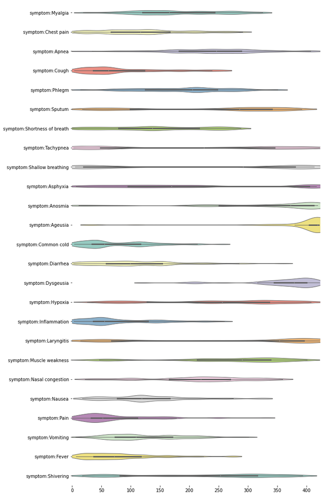

```python
# Set up the matplotlib figure
f, ax = plt.subplots(figsize=(10, 20))

# Draw a violinplot with a narrower bandwidth than the default
sns.violinplot(data=coef_abs_rank_df[selected_predictors], palette="Set3", bw=.2, cut=1, linewidth=1,
              orient="h")

# Finalize the figure
ax.set(xlim=(0, 423))
sns.despine(left=True, bottom=True)
```

Due the hugh variance in geographical coverage, we should be careful when considering the plot above. We get the absolute values of coefficients from the linear regression model and calculate the rank. Here in the violin plot, we draw the distribution of rank across different states. Compared with the model using data for all of the counties to train, we achieve much smaller mse (e.g. ~3-7) for certain states. For the rest, the mse can range from <10 to > 1000.

#### Train on data for all counties

```python
X = df.loc[:, all_predictors].fillna(0)
y = df.loc[:, "cases"].fillna(0)
X_train, X_test, y_train, y_test = train_test_split(X, y, test_size=0.10, random_state=3)

# Train the model
reg = LinearRegression().fit(X_train[best_predictor_set[0]].values , y_train)
pred = reg.predict( X_test[best_predictor_set[0]].values )
mse = mean_squared_error(pred, y_test)
```

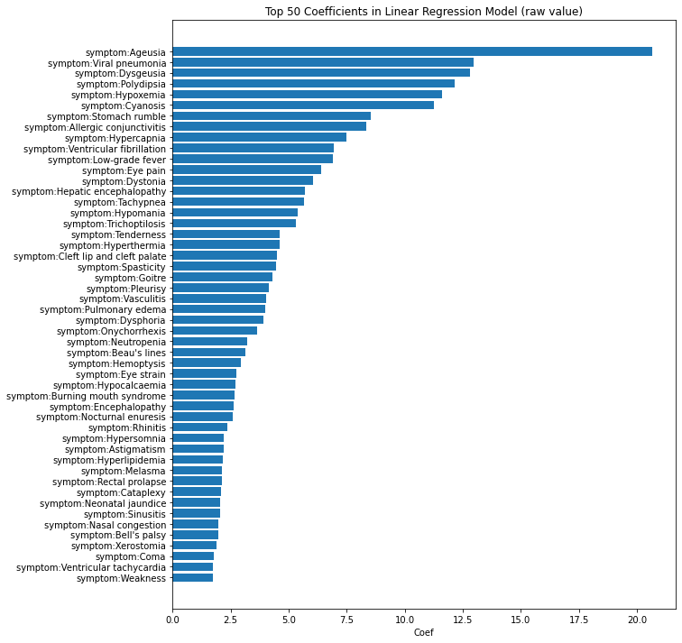

```python
sorted_idx = np.argsort(reg.coef_)
pos = np.arange(50) + .5

plt.figure(figsize = (10, 12))
plt.barh(pos, reg.coef_[sorted_idx][-50:], align='center')
plt.yticks(pos, np.array(all_predictors)[sorted_idx][-50:])
plt.xlabel('Coef')
plt.title('Top 50 Coefficients in Linear Regression Model (raw value)')
```

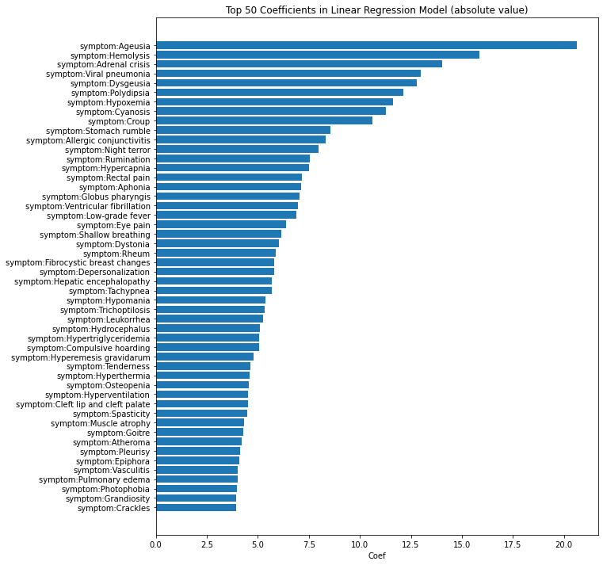

```python
coefs = [abs(x) for x in reg.coef_]
sorted_idx = np.argsort(coefs)
pos = np.arange(50) + .5

plt.figure(figsize = (10, 12))
plt.barh(pos, np.array(coefs)[sorted_idx][-50:], align='center')
plt.yticks(pos, np.array(all_predictors)[sorted_idx][-50:])
plt.xlabel('Coef')
plt.title('Top 50 Coefficients in Linear Regression Model (absolute value)')
```